# Language Modeling

Introduction to NLP — MSc. DH ENC-PSL

Noé Durandard (noe.durandard@psl.eu)

October 14, 2026

# 1 Recap

- Tokenization: `raw text` → `discrete tokens` from Vocabulary
  - Different methods: rule-based (whitespaces), subword (BPE)
- Word Vector Representations / Embeddings
  - OHE, word-word co-occurence: long, sparse vectors (dimension: $|\mathcal{V}|$)
  - Word2Vec: short, dense vectors (dimension: $d\ll|\mathcal{V}|$)
  - Integration of the *distributional hypothesis* to build a geometric *semantic space*
- Semantic Vector Spaces exploration
  - Cosine Similarity: $\text{cossim}\left(\mathbf{x},\mathbf{y}\right)=\frac{\mathbf{x}\cdot\mathbf{y}}{\lVert\mathbf{x}\rVert\lVert\mathbf{y}\rVert}=\cos\left(\theta\right)$
  - Cosine distance: $\text{cosdist}\left(\mathbf{x},\mathbf{y}\right)=1-\text{cossim}\left(\mathbf{x},\mathbf{y}\right)=1-\frac{\mathbf{x}\cdot\mathbf{y}}{\lVert\mathbf{x}\rVert\lVert\mathbf{y}\rVert}=1-\cos\left(\theta\right)$

`Word2Vec` applied to: Semantic Shift & Vector-spaces Alignment

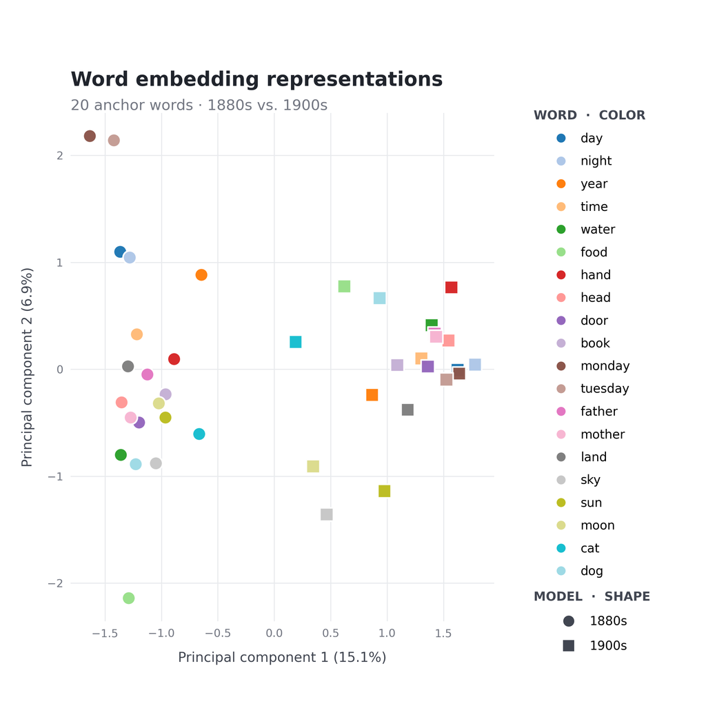

Unaligned representations, projected with PCA.

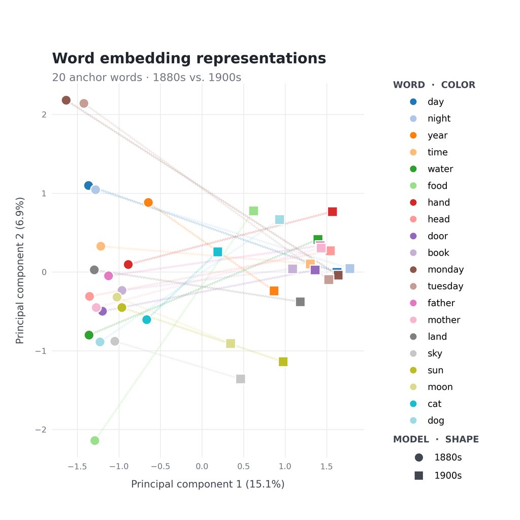

Orthogonal Procrustes Alignment:
$$W^\star=\underset{W}{\mathrm{min}}\lVert\mathbf{X}\mathbf{W}-\mathbf{Y}\rVert_F$$

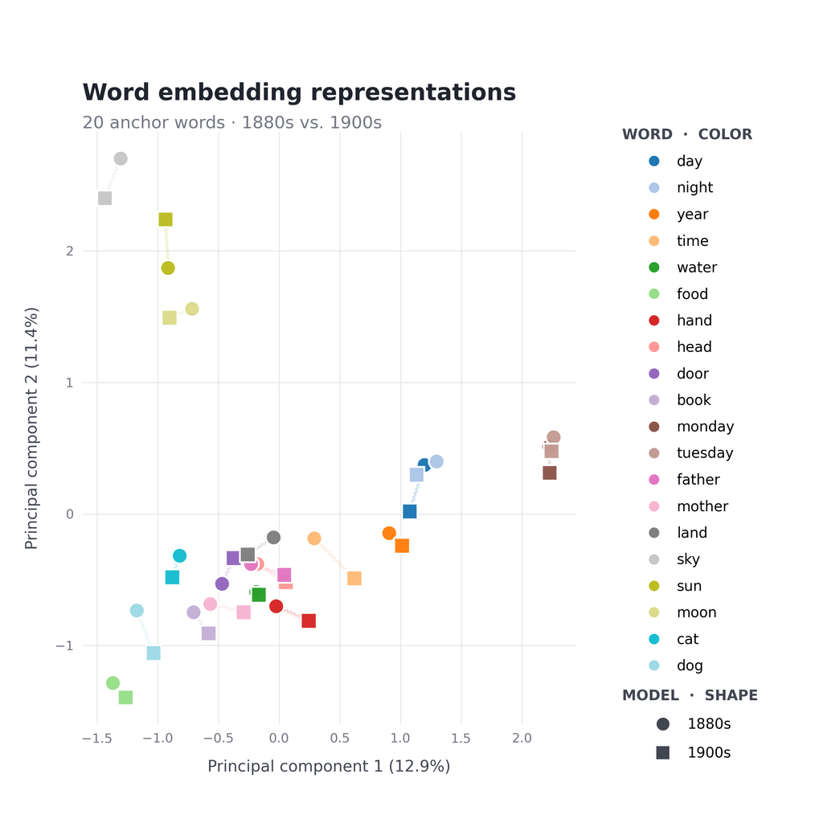

Procrustes aligned representations, projected with PCA.

# 2 Introduction to Language Modeling

## 2.1 Foundations and Objectives

### 2.1.1 Modeling

- What do you expect from a **model**?

```
- simulate behaviour of the real world
- understand which events are in better agreement with the world
- predict the next event given a description of "context" (current state)
```

- What about **language**?

```
- Same!
- But what are these *events*?
```

[figure not shown]

[figure not shown]

### 2.1.2 Modeling Langague

The *linguistic events* used in Language Models are **linguistic unit**: text, sentence, word, token, character, …

**Reminder**

We defined **tokenization** as the process of breaking down text flow into discret units.

- The *tokens* are the *atomic units* to model language, their choice may depend on the application (context-dependent).

/!\ always make sure all your NLP modules use same notion of *tokens* /!\

### 2.1.3 Language Modeling Problem

**Language Model**

A Language Model (LM) estimates the probability of pieces of text.

Given a sequence of text $w_{1},w_{2},\cdots,w_{S}$, it answers the question:

**What is $P(w_{1},w_{2},\cdots,w_{S})$?**

### 2.1.4 LMs play the role of …

- … a judge of **gramaticality**
  - e.g. *“The player runs.”* vs. *“The player run.”*
- … a judge of **semantic plausability**
  - e.g. *“The teacher spoke.”* vs. *“The blackboard spoke.”*
- … an enforcer of **stylistic consistency**
  - e.g. *“In conclusion, the results substantiate the proposed hypothesis.”* vs. *“In conclusion, the results totally back up the proposed hypothesis.”*
- … a repository of **knowledge (?)**
  - e.g. *“Zinedine Zidane played for Real Madrid.”* vs. *“Zinedine Zidane played for Paris 13 Atletico.”*
  - /!\ Very difficult to guarantee!

### 2.1.5 *So… Word2Vec?*

**$\to$ Was Word2Vec doing Language Modeling all along?**

**Predictive Objective**

Recall the skip-gram algorithm $\to$ given a **Center Word** ($c$), predict its surrounding **Context Words** ($o$): $P(o \mid c, \theta)$.

It is trained to minimize:

$$-\frac{1}{|\mathcal{C}|}\sum_{c=1}^{|\mathcal{C}|}\sum_{-m\leq j\leq m, j\neq 0} \log\left( P(w_{c+j}| w_c)\right)$$

**… but not quite**

- Frames language modeling as a *fake task*
  - During training, to extract representations
- No sequential joint probability
  - Does not compute $P(w_1, \dots, w_S)$; assumes conditional independence and computes local probabilities
  - Cannot evaluate entire sequences

### 2.1.6 How to get there?

Recall:

**Language Model**

A Language Model (LM) estimates the probability of pieces of text.

How to compute: $P(w_{1},w_{2},\cdots,w_{S})$?

- Gain knowledge from corpora.
- **Different formalisms to compute $P$**

What is the most probable piece of text?

1. *I like Digital Humanities*
2. *Humanities like I Digital*
3. *I likes Digital Humanities*
4. *I bike Digital Humanities*

$\to$ quite intuitive, but how are machines supposed to understand it?

# 3 From n-grams to Neural LMs

## 3.1 $n$-gram models

### 3.1.1 Reminder: Probabilities

Conditional Probabilities:
$$P(B|A) = P(A,B)/P(A)\ \Leftrightarrow\ P(A,B)=P(A)P(B|A)$$

The Chain Rule in general:
$$\begin{align}
P(x_1,x_2,x_3,\cdots x_S) =&\ P(x_1)P(x_2|x_1)P(x_3|x_1,x_2) \\
&\quad \cdots P(x_S|x_1,x_2,x_3,\cdots x_{S-1}) \\
=& \prod_{i=1}^{S} P(x_i|x_1\cdots x_{i-1})
\end{align}$$

### 3.1.2 $(n-1)$ Markov Assumption

State *only* depends on $(n-1)$ preceeding states:

$P(x_i|x_1\cdots x_{i-1}) \approx P(x_i|$$x_{i-n+1}$$\cdots x_{i-1})$

$\\$

$\Rightarrow P(x_1,x_2,x_3,\cdots x_S)$

$\approx \prod_{i=1}^S P(x_i|$$x_{i-n+1}$$\cdots x_{i-1})$

$\to$ reduces “context” and allows simple (count-based) computation of $n$-gram probabilities.

The parameters of the model are: $P(x_i\cdots x_{i+n-1})$, which can be estimated on some corpus.

### 3.1.3 Unigram

$P(w_{1},w_{2},\cdots,w_{S}) = \prod_i P(w_i) = P(w_1)P(w_2)\cdots P(w_S)$

$\to$ What is the most probable sequence?

$P(\text{the a the a the a})$

$=P(\text{the})P(\text{a})P(\text{the})P(\text{a})P(\text{the})P(\text{a})$

$\\$

$P(\text{the cat sat on the mat})$

$=P(\text{the})P(\text{cat})P(\text{sat})P(\text{on})P(\text{the})P(\text{mat})$

### 3.1.4 Bigram

$P(w_{1},w_{2},\cdots,w_{S}) = \prod_i P(w_i|w_{i-1}) = P(w_1)P(w_2|w_1)\cdots P(w_S|w_{S-1})$

$\to$ What is the most probable sequence?

$P(\text{the a the a the a})$

$=P(\text{the})P(\text{a|the})P(\text{the|a})P(\text{a|the})P(\text{the|a})P(\text{a|the})$

$\\$

$P(\text{the cat sat on the mat})$

$=P(\text{the})P(\text{cat|the})P(\text{sat|cat})P(\text{on|sat})P(\text{the|on})P(\text{mat|the})$

### 3.1.5 Generation with $n$-gram

- n-gram model *knows* (/has learned) distribution of sizes ≤ n
  - e.g. unigram: $P(\text{the})$, bigram: + $P(\text{the cat})$
- next-word probability distribution over vocabulary can be inferred: $p(w_{S+1}|w_{S-n+1}\cdots w_S)$

*The students opend their [?]*

$\to$ $4$-gram model: $p(\text{?}|\text{students opened their})$

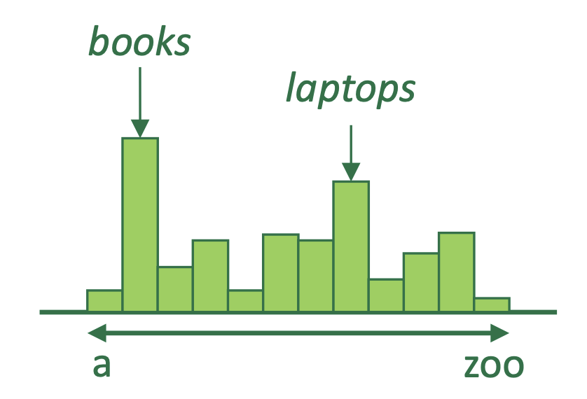

Sample from distribution: $\to$ *The students opend their books*

### 3.1.6 Simple but limited paradigm

Why n-grams?

- Simple and fast.
- Effective for short frequent sequences.
- Clear paradigm introducing important issues for (L)LMs.
  - Training, evaluation, sampling, etc. (we’ll come back to this)

**Foundational model**

Limitations:

- Data sparsity.
  - Scales badly with $n$.
- Rigid context window.
  - can’t handle long dependencies.
- No sense of meaning.

## 3.2 Neural Language Models

### 3.2.1 Timeline

100+ years of LMs in 30s:

- **1906:** Markov – Statistical modeling of sequences
- **1948:** Shannon – Information theory and early ideas of statistical prediction of text
- **1980s–1990s:** Back-off and smoothing, probabilistic grammars
- **2003:** *Neural Probabilistic Language Model* (Bengio et al. 2003)
  - First to learn **distributed representations (embeddings)** jointly with next-word prediction
- **2010s:** Recurrent Neural Networks (RNNs), LSTMs, GRUs
  - Allowed *dynamic* context windows
- **2017:** *Attention is All You Need* (Vaswani 2017)
  - self-attention mechansim, drastically reduces training costs
- **2018—:** Pre-trained LLMs + scaling
  - BERT (Devlin et al. 2019)
  - GPT (Radford et al. 2018)

### 3.2.2 Different paradigm

**Language Modeling problem**

*How to compute $P(w_{1},w_{2},\cdots,w_{S})$ or $P(w_i|w_1\cdots w_{i-1})$?*

**Count-based models**: rely on explicit co-occurrence counts.

$P(w_i|w_1\cdots w_{i-1})\approx\frac{\mathrm{C}(w_{i-n+1}\cdots w_{i-1}w_i)}{\mathrm{C}(w_{i-n+1}\cdots w_{i-1})}$

**Neural models**: learn a function $f_\Theta$ that models NL

$$P(w_i|w_1\cdots w_{i-1})=f_{\Theta}(w_{1},w_{2},\cdots,w_{i-1})$$

$\to$ + based on continuous vector embedding (make semantic emerge).

### 3.2.3 Neural Probabilistic LM (Bengio et al. 2003)

$$P(w_t|w_{t-n+1:t-1}) = \text{softmax}(g_\theta(e(w_{t-n+1}),\dots,e(w_{t-1})))$$

- Core ideas:
  - Represent each word as an **embedding vector** (dense representation).
  - Concatenate embeddings of previous $(n-1)$ words.
  - Feed to a feedforward neural network to predict next word probability.

✅ Captures semantic similarity  
🚫 One vector per word → doesn’t handle polysemy 🚫 Fixed-size context → still limited like n-gram

### 3.2.4 Recurrent Neural Networks (RNNs)

**Motivation**

- Fixed-size context of feedforward models is too restrictive.
- Need a model that can handle *arbitrary-length* context.

**RNN idea:**

- Maintain a **hidden state** summarizing all past words.
- Update recurrently:
  $$h_t = f(W_{xh}x_t + W_{hh}h_{t-1})$$
  $$P(w_t|w_{1:t-1}) = \text{softmax}(W_{ho}h_t)$$

#### 3.2.4.1 RNN Architecture

- The same weights are used at each time step → efficient and general.
- Capable to capture long-range dependencies.

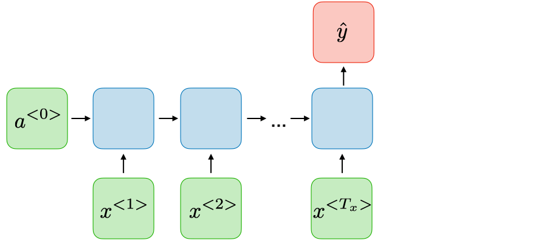

RNN Architecture (from (Amidi and Amidi 2018)).

**Note**

Many variants have been developed, e.g. **Long Short-Term Memory (LSTM)** to control information flow (Hochreiter and Schmidhuber 1997) (+later bi-LSTM, context from both sides), Gated Recurent Units (GRUs) simplified approach (Cho et al. 2014). Both mitigate the vanishing gradients arising in traditional RNNs and allow longer dependencies.

#### 3.2.4.2 Limitations of RNNs

- Difficult to capture very long dependencies
  - even with LSTMs.
- Memory bottleneck
  - all context must fit into one hidden vector.
- Slow to train and not prone to parallelization
  - Sequential, recurrent, nature.

$\to$ These challenges motivated **attention mechanisms** and the **Transformer** architecture.

# 4 Transformer

## 4.1 Motivation

- Need to use more information
  - Take advantage of full context
  - whole sentences available during training
  - why go through sentence word by word?
- Need to improve efficiency
  - Allows parallelization.
  - Based on matrices products.
  - Much faster to train than predecessors.

$\to$ Transformers (with variations) have became standard models for (any) LM tasks.

## 4.2 *Attention is All You Need* (Vaswani 2017)

[interactive chart not shown]

## 4.3 The Transformer Architecture

### 4.3.1 Overview

- Encoder / Decoder Model
  - Building blocks are $\approx$ similar
- Originally applied to machine translation
  - Foundational for many modern approaches
  - not limited to natural language! (vision, proteins, audio, …)
- Layered approach
  - $\to$ model sequentially builds intricate understanding.

[figure not shown]

*Transformer Architecture*, based on (Vaswani 2017), reworked from (Zhang et al. 2023).

### 4.3.2 Input: Embedding + Positional encoding

1. Tokenization
   - Breaking text into smaller units (from vocabulary).
2. Token Embedding
   - Associate token with dense vectors (ID $\to$ vector).
3. Positional Encoding
   - Encode information about token’s positions.
   - 💡: No direct notion of word order in attention.
4. Combine: Semantic + Order

[figure not shown]

*Transformer Architecture*, based on (Vaswani 2017), reworked from (Zhang et al. 2023).

### 4.3.3 Self-attention Mechanism

- Capture relationships among tokens in a sequence.
- Split between Multi-Head Attention.

#### 4.3.3.1 Intuition: Information Look-up

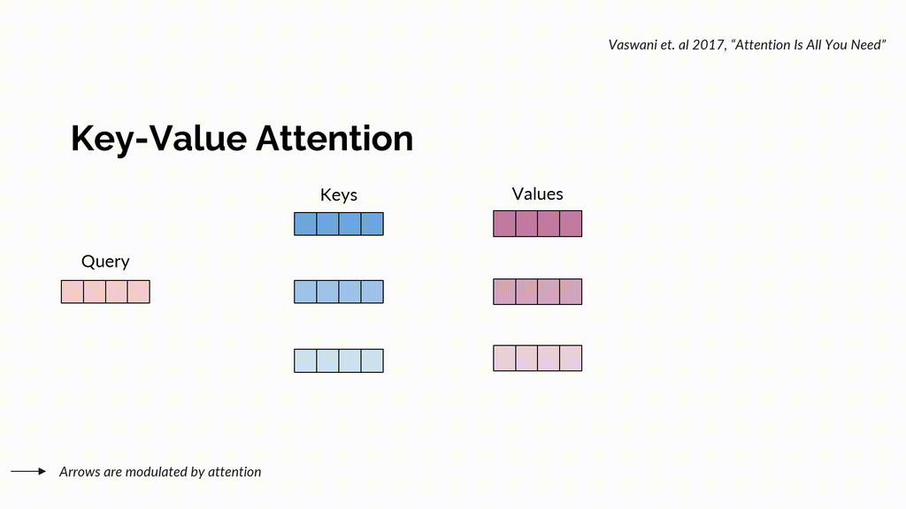

Extracted from (Mittal 2024).

#### 4.3.3.2 Under the hood: Matrices Multiplications

$$\mathrm{Attention}(Q,K,V)=\mathrm{softmax}\left(\frac{QK^{T}}{\sqrt{d_k}}\right)V$$

where, for a given input $X\in\mathbb{R}^{N\times d}$ and *learnable* projection matrices $W^Q\in\mathbb{R}^{d\times d_k}$, $W^K\in\mathbb{R}^{d\times d_k}$, and $W^V\in\mathbb{R}^{d\times d_v}$:

$$Q=XW^Q,\quad K=XW^K,\quad V=XW^V$$

$\to$ can be parallelized on GPUs!

#### 4.3.3.3 Query-Key-Value

- $Q$: asking information.
- $K$: presenting information.

$\to$ $QK^T$: *attention weights* from one word to another.

- $V$: giving information.

$\to$ information flow scaled by *attention weights*.

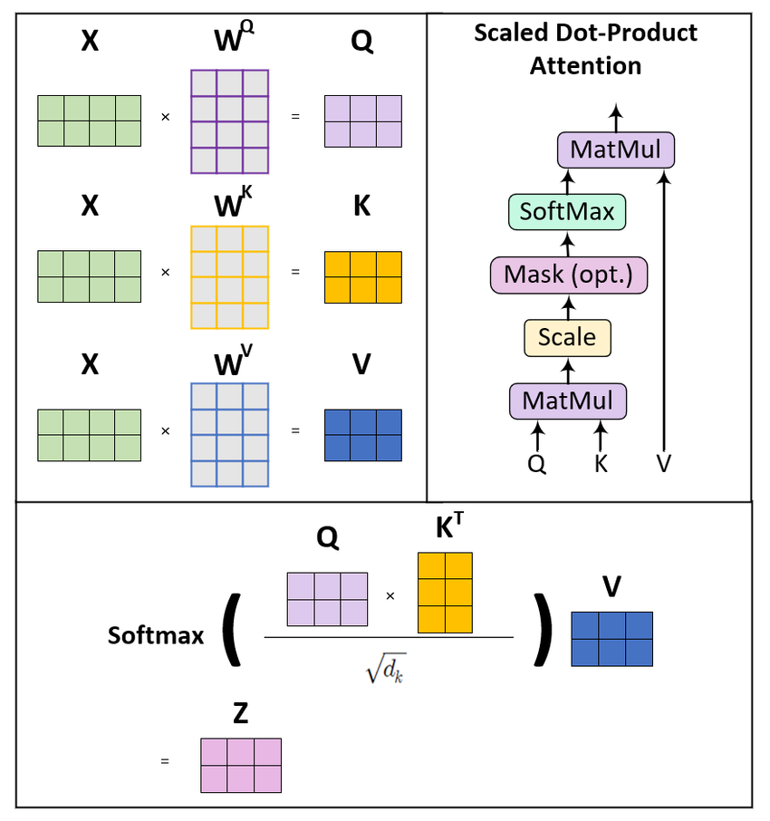

Diagram of the query, key, value, and self-attention mechanism (from (Hwang, Jeong, and Hwang 2025)).

### 4.3.4 Multi-Head Attention

- **Intuition:** independent “heads” can learn to capture different linguistic relationships.
  - e.g. syntactic, semantic, short-/long- range dependencies, …
- **Implementation:** several attention mechanisms then concatenated.

Think of: “The cat chased the mouse in the garden.”

[figure not shown]

*Transformer Architecture*, based on (Vaswani 2017), reworked from (Zhang et al. 2023).

### 4.3.5 Feed Forward Network

- **Intuition:** self-attention captures relationships between tokens, FFN refines token-wise representations.
- **Implementation:** two linear layers with ReLU in-between: $\mathrm{FFN}(x)=max\left(0, xW_1+b_1\right)W_2+b_2$
  - Adds non-linearity.
  - Enrichment through expansion-compression.

[figure not shown]

*Transformer Architecture*, based on (Vaswani 2017), reworked from (Zhang et al. 2023).

### 4.3.6 Residual Connections & Normalization

More technicalities: facilitate information flow and convergence.

- **Residual Connections**
  - Ease gradient flow.
  - Allow stacking lots of layers.
- **Layer Normalization**
  - Control “flow” to next layer.
  - Improves convergence stability.

[figure not shown]

*Transformer Architecture*, based on (Vaswani 2017), reworked from (Zhang et al. 2023).

### 4.3.7 Summary

- Positional Encoding:
  - retains information of the word order.
  - enables parallelization and efficient model training.
- Self-Attention Mechanism:
  - global look-up in a sequence.
  - allows direct dependencies.
  - fully parallel.
- Multi-Head Attention:
  - jointly attend to information from different representation subspaces at different positions.
  - provide several perspectives.
  - enhances training stability.
  - effectiveness and optimality discussed in recent literature ((Liu, Liu, and Han 2021), (Mittal et al. 2022)).
- Feed Forward Network:
  - non-linearly transforms input tokens independently.
  - promotes high-level concepts (Geva et al. 2022).
- Skip Connections & Normalization:
  - stabilise training.
  - ease information flow.

*Transformer Architecture*, based on (Vaswani 2017), reworked from (Zhang et al. 2023).

## 4.4 A metaphorical view of Transformer

### Transformer = Support Groups

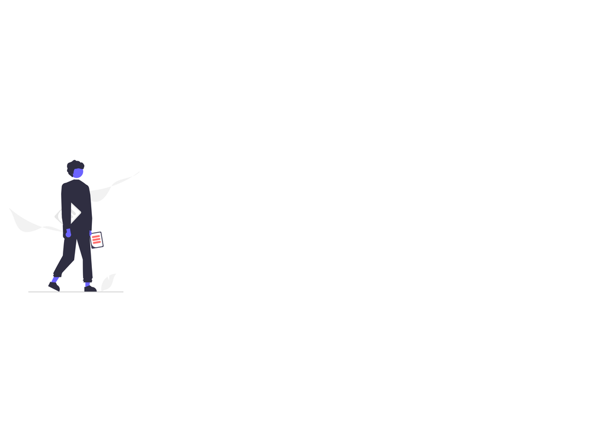

### Transformer = Support Groups

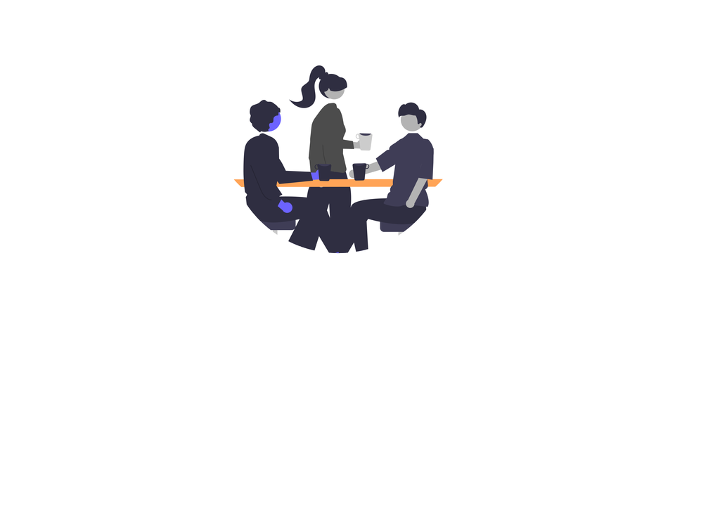

### Transformer = Support Groups

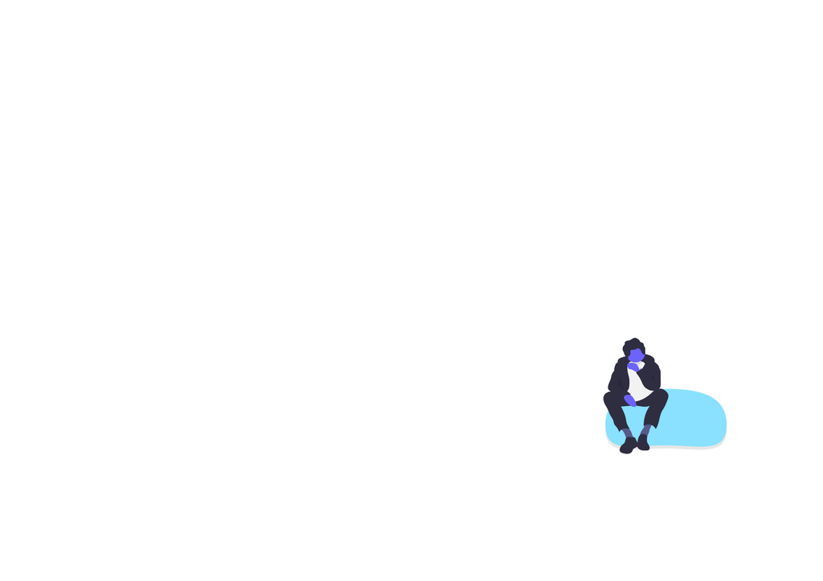

### Transformer = Support Groups

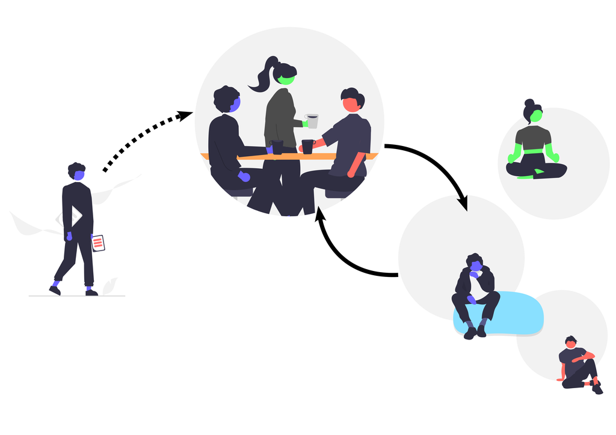

### Transformer = Support Groups

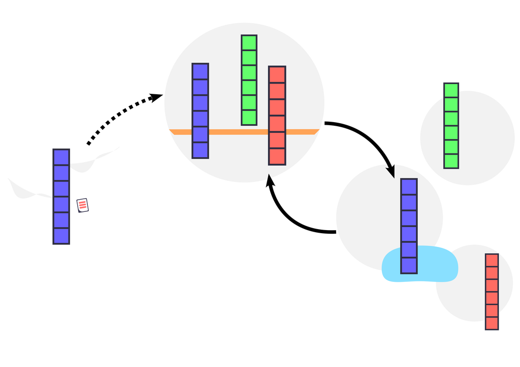

# 5 Pre-trained Transformer Models

## 5.1 NLP Pipeline

### 5.1.1 Back in the days

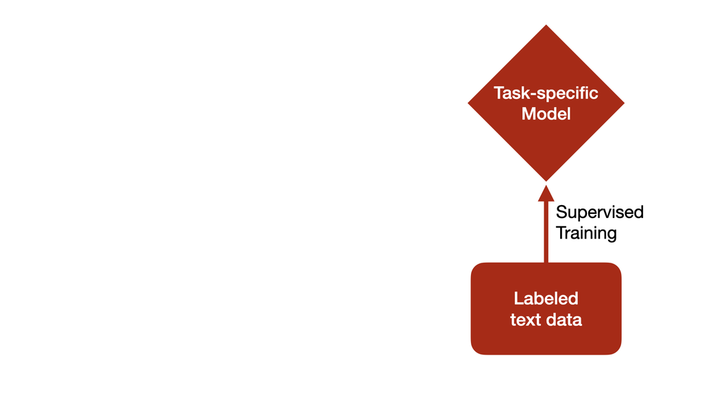

### 5.1.2 Adapting pre-trained models

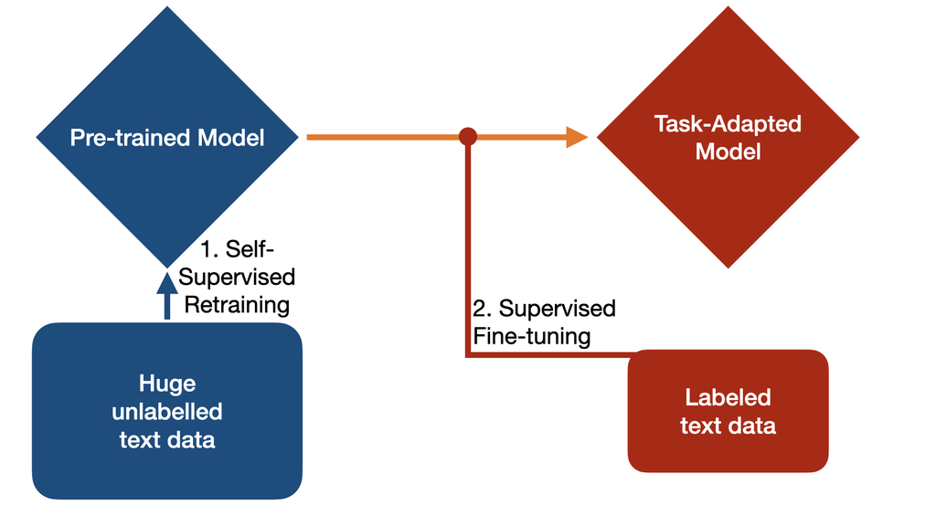

### 5.1.3 Directly prompting

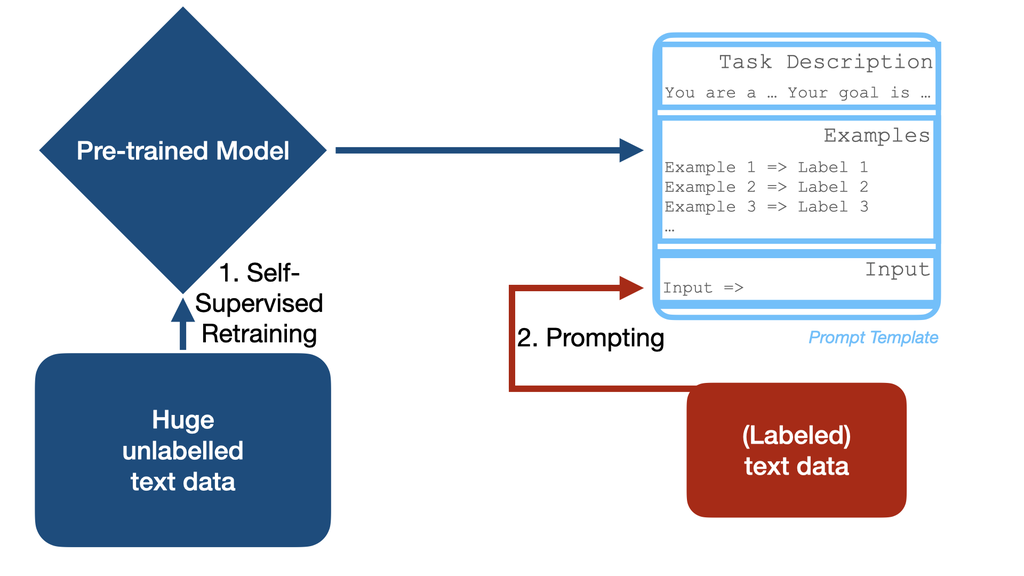

## 5.2 Taxonomy of pre-trained LMs

### 5.2.1 Variations in architectures and objectives

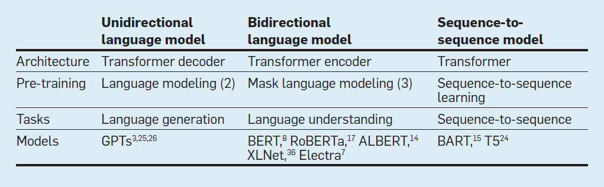

Overview of pre-trained LM types (from (Li 2022)).

### 5.2.2 Causal Language Modeling (Decoder)

Predict the **next** token in sequence: $P(w_t \mid w_1, w_2, \dots, w_{t-1})$

*Recently, my friend tapao 20 packets of **_______***

- Attends to **left-context** only.
- Great for natural language **generation** (… and more?).
- Example: GPTs.

$\to$ We’ll come back to this later.

### 5.2.3 Masked Language Modeling (Encoder)

Predict a **masked** token: $P(w_{\text{MASK}} \mid w_{\text{left context}}, w_{\text{right context}})$

*Recently, my friend **_____** 20 packets of kolo me*

- Attends to **left- and right- context** simultaneously (fully bidirectional).
- Great for tasks that require a good **contextual understanding** of an entire sequence.
- Example: BERT-like models.

## 5.3 Focus on BERT (Devlin et al. 2019)

### 5.3.1 From static to dynamic embeddings

|  | Word2Vec | BERT |
| --- | --- | --- |
| **Architecture** | Shallow neural network / Matrix factorization | Multi-layer bidirectional Transformer encoder |
| **Contextualization** | **Static**: During training; one vector per word type $(\vec{v}_{\text{digit}})$ | **Dynamic**: At inference time; function of the entire sequence / context $(\mathbf{h}_{\text{digit}}^{(l)})$ |
| **Handling Polysemy** | ❌ | ✅ |

**Contextualized Embeddings** of the token `digit` across occurences in the CoarseWSD-20 dataset (Loureiro et al. 2021):

[interactive chart not shown]

### 5.3.2 BERT Specificities

**BERT vs other Transformer models**

- Original Transformer
  - Encoder & Decoder
  - Sequence-to-Sequence tasks (MT)
- GPT models
  - Decoder-only
  - Text generation

**BERT Key Features**

- Encoder-only
- True bidirectionality
- Training objectives
  - **Masked Language Modeling (MLM)**: Randomly `[MASK]` 15% of input tokens; learn to predict $\Rightarrow$ build rich, bidirectional contextual representations.
  - Next Sentence Prediction (NSP): Predict whether sentence B follows sentence A $\Rightarrow$ capture relationships between sentences.
  - *NSP much less central in later variants*

$\to$ BERT focuses on natural language understanding (NLU) and representation learning.

### 5.3.3 BERT Processing

[figure not shown]

*Transformer Encoder Architecture*, based on (Vaswani 2017), reworked from (Zhang et al. 2023).

### 5.3.4 BERT Embeddings

- **Hidden State Representations**  
  (e.g., Tenney, Das, and Pavlick 2019):
  - **Lower layers**: Surface syntax, morphology, local patterns
  - **Higher layers**: Semantics, discourse, pragmatic context
- **Choosing the *right* vector**
  - At each layer: $(N_\mathrm{batch}\times)\ N_\mathrm{tokens}\times d_\mathrm{model}$
  - **Layer**: top layer ($\mathbf{h}_i^{(L)}$); other layer ($\mathbf{h}_i^{(l)}$); mean-pooling over layers; concatenation; …
  - **Position**: position of the token; `CLS` token; mean-pooling over tokens
  - $\to$ *‘Right’ choice sually depends on the task, and often results from heuristics or empirical choice.*

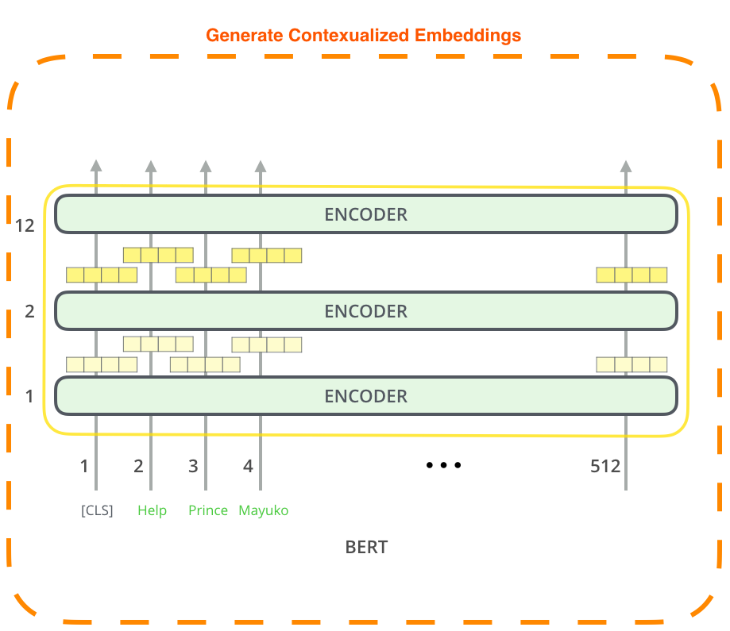

Extracted from *[The Illustrated BERT, ELMo, and co.](https://jalammar.github.io/illustrated-bert/) by Jay Alammar.*

## 5.4 Practical Ecosystem: Hugging Face

### 5.4.1 Where to find pre-trained LMs?

You can find, access (and share) open-weights LLMs on [HuggingFace](https://huggingface.co).

[figure not shown]

Screenshot of https://huggingface.co.

### 5.4.2 How to use them?

```python
from transformers import AutoTokenizer, AutoModel

model_name = "bert-base-uncased" # choose a model from HF

# Load pre-trained model & tokenizer
tokenizer = AutoTokenizer.from_pretrained(model_name)
model = AutoModel.from_pretrained(model_name)

# Extract dynamic contextual embeddings
inputs = tokenizer(
  "The cat didn't cross the street because it was too wide.",
  return_tensors="pt"
)
outputs = model(**inputs)

# Hidden state vector shape: [batch_size, sequence_length, hidden_dim]
last_hidden_states = outputs.last_hidden_state
```

# 6 [Hands-on](https://github.com/d-noe/NLP_DH_F26/tree/main/code/3_bert_training)

1. [Turial 3a - Discover BERT](https://github.com/d-noe/NLP_DH_F26/blob/main/code/3_bert_training/Tutorial_3a_Discover_BERT.ipynb)
   - Familiarize with BERT, and inspect the inner mechanisms of the model.
2. [Tutorial 3b - Word Sense Disambiugation](https://github.com/d-noe/NLP_DH_F26/blob/main/code/3_bert_training/Tutorial_3b_WSD.ipynb)
   - Extract representations from BERT and use them to disambiguate the meaning polysemeous words
3. [Hands-on 3 - Semantic Shift with BERT](https://github.com/d-noe/NLP_DH_F26/blob/main/code/3_bert_training/Hands_on_3_SS.ipynb)
   - Extract representations from BERT to analyse semantic shifts using data from the *Living With Machines* Initiative.
4. [[Bonus] Guided Lab 3 - NER with BERT](https://github.com/d-noe/NLP_DH_F26/blob/main/code/3_bert_training/Guided_lab_3_NER.ipynb)
   - Adapt a pre-trained BERT-like model to perform Named Entity Recognition (NER) on a corpus of historical newspapers in French (from the *CLEF-HIPE-2020 shared task*).

## References

Amidi, Afshine, and Shervine Amidi. 2018. “Recurrent Neural Networks Cheatsheet Star.” *CS 230 - Recurrent Neural Networks Cheatsheet*. https://stanford.edu/~shervine/teaching/cs-230/cheatsheet-recurrent-neural-networks#.

Bengio, Yoshua, Réjean Ducharme, Pascal Vincent, and Christian Jauvin. 2003. “A Neural Probabilistic Language Model.” *Journal of Machine Learning Research* 3 (Feb): 1137–55.

Cho, Kyunghyun, Bart Van Merriënboer, Dzmitry Bahdanau, and Yoshua Bengio. 2014. “On the Properties of Neural Machine Translation: Encoder-Decoder Approaches.” *arXiv Preprint arXiv:1409.1259*.

Devlin, Jacob, Ming-Wei Chang, Kenton Lee, and Kristina Toutanova. 2019. “BERT: Pre-Training of Deep Bidirectional Transformers for Language Understanding.” https://arxiv.org/abs/1810.04805.

Geva, Mor, Avi Caciularu, Kevin Wang, and Yoav Goldberg. 2022. “Transformer Feed-Forward Layers Build Predictions by Promoting Concepts in the Vocabulary Space.” In *Proceedings of the 2022 Conference on Empirical Methods in Natural Language Processing*, edited by Yoav Goldberg, Zornitsa Kozareva, and Yue Zhang, 30–45. Abu Dhabi, United Arab Emirates: Association for Computational Linguistics. https://doi.org/10.18653/v1/2022.emnlp-main.3.

Hochreiter, Sepp, and Jürgen Schmidhuber. 1997. “Long Short-Term Memory.” *Neural Computation* 9 (8): 1735–80.

Hwang, Hae-Ji, Seon-Geun Jeong, and won-Joo Hwang. 2025. “Ultrawideband Non-Line-of-Sight Classification Using Transformer-Convolutional Neural Networks.” *IEEE Access* PP (January): 1–1. https://doi.org/10.1109/ACCESS.2025.3568830.

Li, Hang. 2022. “Language Models: Past, Present, and Future.” *Communications of the ACM* 65 (7): 56–63. https://doi.org/10.1145/3490443.

Liu, Liyuan, Jialu Liu, and Jiawei Han. 2021. “Multi-Head or Single-Head? An Empirical Comparison for Transformer Training.” https://arxiv.org/abs/2106.09650.

Loureiro, Daniel, Kiamehr Rezaee, Mohammad Taher Pilehvar, and Jose Camacho-Collados. 2021. “Analysis and Evaluation of Language Models for Word Sense Disambiguation.” https://arxiv.org/abs/2008.11608.

Mittal, Sarthak. 2024. “Compositional Attention: Disentangling Search and Retrieval.” *Mila*. Mila. https://mila.quebec/en/article/compositional-attention-disentangling-search-and-retrieval.

Mittal, Sarthak, Sharath Chandra Raparthy, Irina Rish, Yoshua Bengio, and Guillaume Lajoie. 2022. “Compositional Attention: Disentangling Search and Retrieval.” https://arxiv.org/abs/2110.09419.

Radford, Alec, Karthik Narasimhan, Tim Salimans, Ilya Sutskever, et al. 2018. “Improving Language Understanding by Generative Pre-Training.”

Tenney, Ian, Dipanjan Das, and Ellie Pavlick. 2019. “BERT Rediscovers the Classical NLP Pipeline.” In *Proceedings of the 57th Annual Meeting of the Association for Computational Linguistics*, edited by Anna Korhonen, David Traum, and Lluís Màrquez, 4593–4601. Florence, Italy: Association for Computational Linguistics. https://doi.org/10.18653/v1/P19-1452.

Vaswani, A. 2017. “Attention Is All You Need.” *Advances in Neural Information Processing Systems*. https://dl.acm.org/doi/10.5555/3295222.3295349.

Zhang, Aston, Zachary C. Lipton, Mu Li, and Alexander J. Smola. 2023. *Dive into Deep Learning*. Cambridge University Press.

Language Modeling

[figure not shown]